# Reproducible Research: Peer Assessment 1

### Loading and preprocessing the data

```r
df<- read.csv(unz("repdata-data-activity.zip", "activity.csv"), header=TRUE ,sep=",")
df$DateField<-as.Date(df$date)
```

### What is mean total number of steps taken per day?

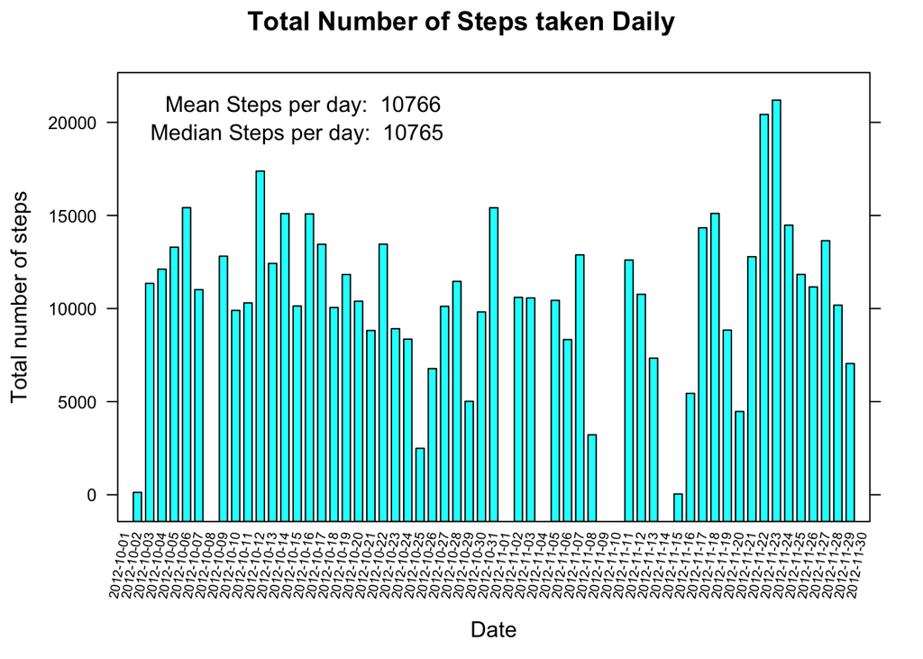

```r
library(lattice)
totalStepsByDate<-aggregate(df$steps, by=list(df$date),FUN=sum)
names(totalStepsByDate)<-c("Date","Steps")
meanPerDay<-mean(totalStepsByDate$Steps,na.rm = TRUE)
medianPerDay<-median(totalStepsByDate$Steps,na.rm = TRUE)
totalStepsPerDayPlot<-barchart(Steps ~ Date, data=totalStepsByDate,
                               main="Total Number of Steps taken Daily",
                               ylab="Total number of steps", xlab="Date",
                               scales = list(y=list(tick.number=6),
                                             x=list(cex=0.6,tick.number=7,rot=80)
                                             ),panel=function(x,y,...){
                               panel.barchart(x,y,...)
                               panel.text(x=x[15],y=21000,paste(c("  Mean Steps per day: ",format(meanPerDay,digits=5)),sep="",collapse=" "))
                               panel.text(x=x[15],y=19500,paste(c("Median Steps per day: ",format(medianPerDay,digits=5)),sep="",collapse=" "))
                               })
print(totalStepsPerDayPlot)
```

The daily **mean** total number of the steps taken per day is **10766** and the **median** total number of steps taken per day is **10765**. *Missing values were excluded in computing the mean and median.*

### What is the average daily activity pattern?

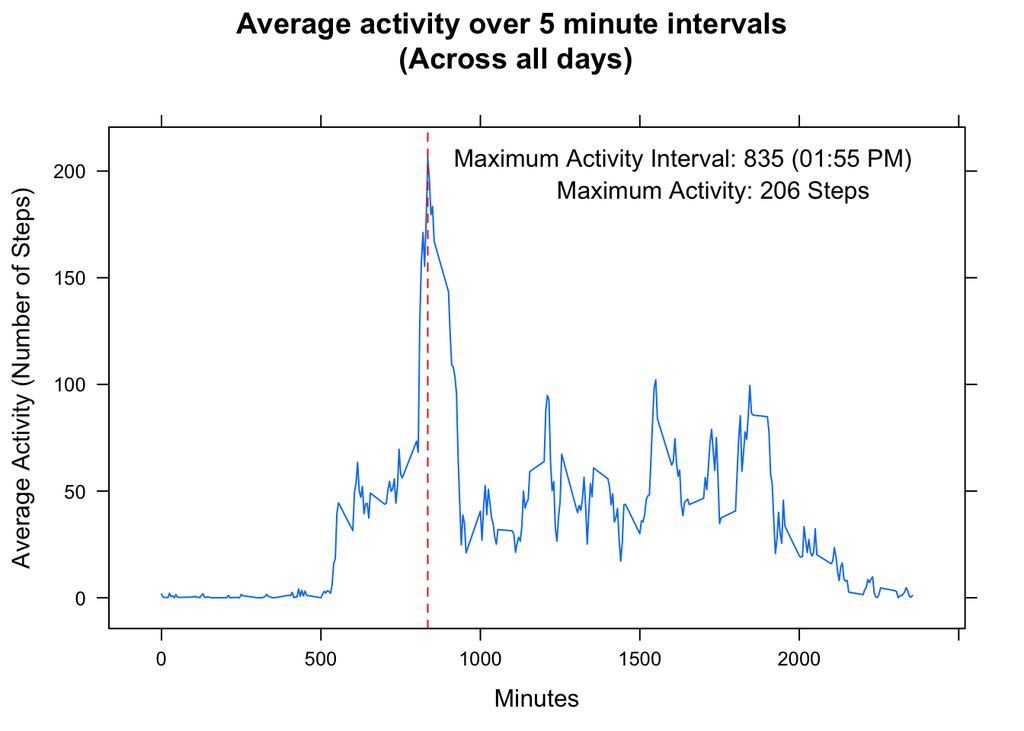

```r
library(lattice)
avgActivity<-aggregate(df$steps, by=list(df$interval),FUN=mean, na.rm=TRUE)
names(avgActivity)<-c("Interval","Activity")
yMax.y<-max(avgActivity$Activity)
yMax.x<-avgActivity$Interval[which.max(avgActivity$Activity)]
yMax.time<-strftime( as.POSIXct( "1970-01-01" ) + as.difftime( yMax.x, units="mins" ), "%I:%M %p" )
maxIntervalLabel<-paste(c("Maximum Activity Interval: ",yMax.x," (",yMax.time,")"),sep="", collapse="")
maxActivityLabel<-paste(c("         Maximum Activity: ",format(yMax.y,digits=3)," Steps"),sep="", collapse="")
avgActivityOver5Mins<-xyplot(Activity ~ Interval, data=avgActivity, type="l",
                             main="Average activity over 5 minute intervals\n (Across all days)",
                             xlab="Minutes", ylab="Average Activity (Number of Steps)",
                             panel=function(x,y,...){
                               panel.xyplot(x,y,...)
                               panel.abline(v =yMax.x,col = "red", lwd = 1, lty="dashed")
                               panel.text(x=yMax.x+800,y=yMax.y,labels=maxIntervalLabel)
                               panel.text(x=yMax.x+800,y=yMax.y-15,labels=maxActivityLabel)
                               })
print(avgActivityOver5Mins)
```

### Imputing missing values

```r
dfi<- read.csv(unz("repdata-data-activity.zip", "activity.csv"), header=TRUE ,sep=",")
dfi$DateField<-as.Date(dfi$date)
dfi$stepsImp<-dfi$steps

dateStr<-unique(dfi$DateField)
for (i in 1:length(dateStr)){
  a<-dfi$stepsImp[dfi$DateField==dateStr[i]]
  #atleast one NA and
  if(any(is.na(a))){
    #has atleast one value
    if(any(!is.na(a))){
      a<-dfi$stepsImp[dfi$DateField==dateStr[i]]
      amean<-mean(a,na.rm=TRUE)
      a[is.na(a)==TRUE]=amean
      dfi$stepsImp[dfi$DateField==dateStr[i]]=a
      }else{
        # has all NAs ==> replace with 0
        dfi$stepsImp[dfi$DateField==dateStr[i]]=0
        }
    }
  }
```

There are 2304 NAs out of total of 17568 observations. Since NAs affect the summary statstics, we explore its variation upon replacing NAs. Current plot shows the affect of replacing the NA values with value for daily mean number of steps for that day. If NAs are observed for an entire day, the mean is assumed to be 0, and all NAs are replaced by 0.

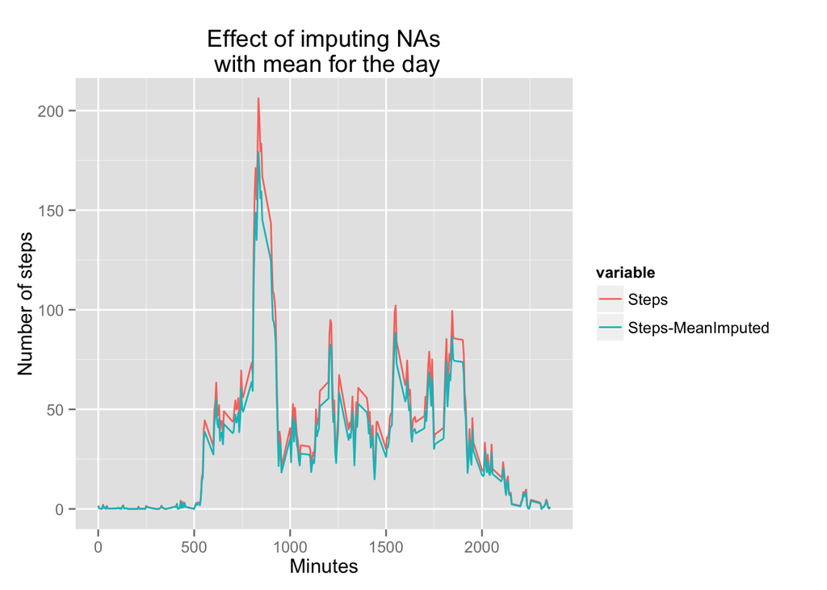

```r
avgsAll<-aggregate(dfi$steps, by=list(dfi$interval),FUN=mean, na.rm=TRUE)
avgImputed<-aggregate(dfi$stepsImp, by=list(dfi$interval),FUN=mean, na.rm=TRUE)
avgsAll$imp<-avgImputed$x
names(avgsAll)<-c("Interval","Steps","Steps-MeanImputed")

totalStepsByDate1<-aggregate(dfi$stepsImp, by=list(dfi$date),FUN=sum)
names(totalStepsByDate1)<-c("Date","StepsImp")

meanPerDay1<-mean(totalStepsByDate1$StepsImp,na.rm = TRUE)
medianPerDay1<-median(totalStepsByDate1$StepsImp,na.rm = TRUE)

library(ggplot2)
library(reshape2)
avgsAll2<-melt(data=avgsAll, id.vars="Interval")
avgImpPlot<-ggplot(data = avgsAll2, aes(x = Interval, y = value, colour = variable)) + geom_line()
avgImpPlot<-avgImpPlot  + labs(x = "Minutes") + labs(y = "Number of steps") + labs(title = "Effect of imputing NAs\n with mean for the day")

print(avgImpPlot)
```

**Figure 3.** *Time series plot of the average number of steps taken during 5-minute intervals across all days (a) NAs not imputed mean = 10766 and median = 10765 (b) Imputing NAs with mean for the day changes the statists to mean = 9354 and median = 10395. If all values for a day are NAs, then mean is assumed to be 0.*

**Imputing NAs with mean lowers the daily Mean and Median number of steps taken.**

### Are there differences in activity patterns between weekdays and weekends?

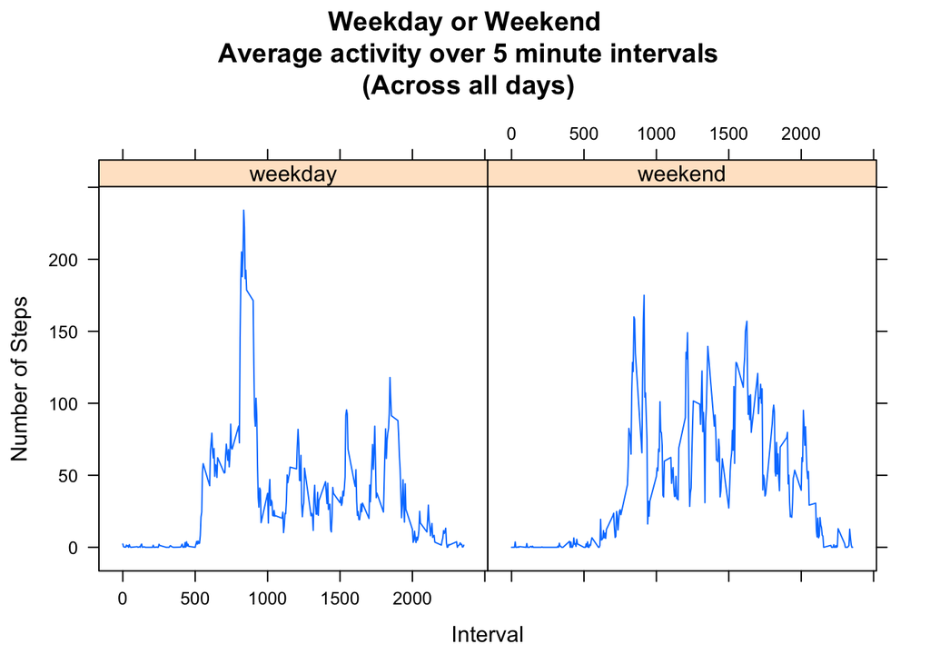

```r
library(lattice)
df$DateField<-as.Date(df$date)
df$DayOfWeek<-factor(weekdays(df$DateField))
df$Weekday<-factor(weekdays(df$DateField))
levels(df$Weekday)<-list(`weekday`=c("Monday","Tuesday","Wednesday","Thursday","Friday"), `weekend`=c("Saturday","Sunday"))
avgStepsByWeekday<-aggregate(df$steps, by=list(df$interval,df$Weekday),FUN=mean, na.rm=TRUE)
names(avgStepsByWeekday)<-c("Interval","Weekday","MeanSteps")
weekdaysTable<-table(df$Weekday)/288
weekdayPlot<-xyplot(MeanSteps ~ Interval|Weekday, data=avgStepsByWeekday, nrow=2,ncol=1, type="l",
                    main="Weekday or Weekend\n Average activity over 5 minute intervals\n (Across all days)",
                    xlab="Interval", ylab="Number of Steps")

print(weekdayPlot)
```

**Figure 4.** *Average activity pattern during weekdays and weekends. The plot show definitive higher acivity during the afternoon period, corresponding to about 800-950 minutes during weekdays(45), while during weekends(16) the activity was higher throughout the day. This is possibly due to a vigorous exercise schedule during weekdays that is no apparent during weekend.*